# Group 25 :Assignment 2.5

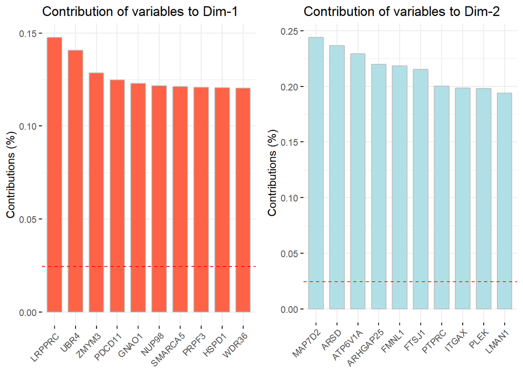

```r
library(gridExtra)

p1 <- fviz_contrib(all_pca, choice="var", axes=1, fill="tomato", color="grey", top=10)
p2 <- fviz_contrib(all_pca, choice="var", axes=2, fill="powderblue", color="grey", top=10)
grid.arrange(p1,p2,ncol=2)
```

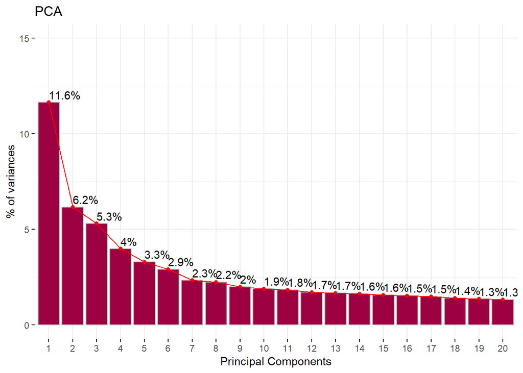

```r
# variance
pr_var = ( all_pca$sdev )^2

# % of variance
PVE = pr_var / sum( pr_var )


# The percentage of variability explained by the principal components can be ascertained through screeplot.
fviz_eig(all_pca, addlabels=TRUE, ylim=c(0,15), geom = c("bar", "line"), barfill = "1", barcolor="grey",linecolor = "red", ncp=20)+
labs(title = "PCA", x = "Principal Components", y = "% of variances")
```

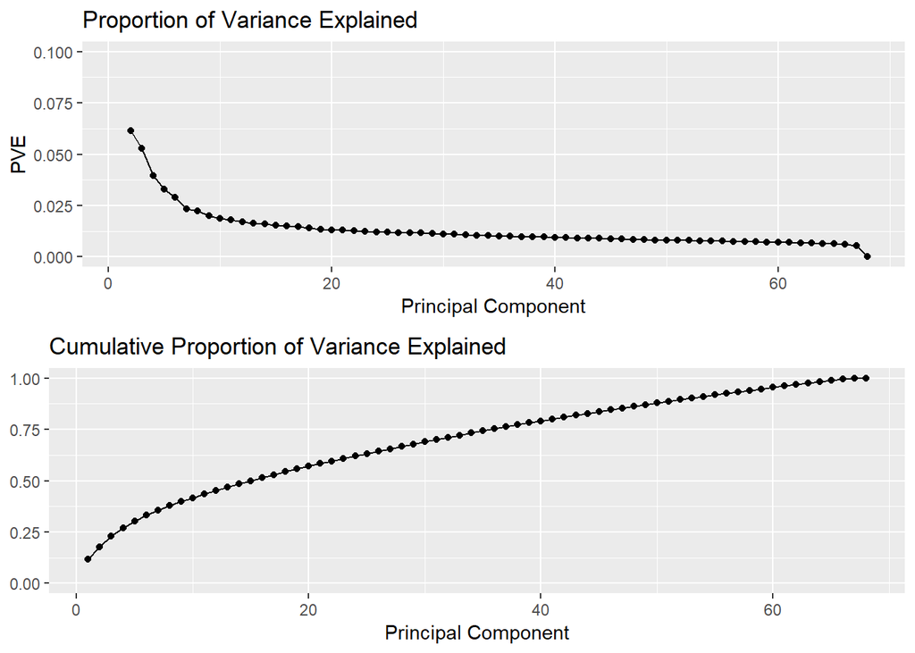

```r
PVEplot <- qplot(c(1:68), PVE) +
  geom_line() +
  xlab("Principal Component") +
  ylab("PVE") +
  ggtitle("Proportion of Variance Explained") +
  ylim(0, 0.1)

# Cumulative PVE plot
cumPVE <- qplot(c(1:68), cumsum(PVE)) +
  geom_line() +
  xlab("Principal Component") +
  ylab(NULL) +
  ggtitle("Cumulative Proportion of Variance Explained") +
  ylim(0,1)

grid.arrange(PVEplot, cumPVE, nrow=2, ncol=1)
```

```r
train_set_pca = data.frame( pcaOutput$x, class = train_set_mda$class )
# train_set_pca[1:5,(ncol(train_set_pca)-5):ncol(train_set_pca)]
```

### 3.3.6 Result

> Random Forest Feature Select improves the prediction

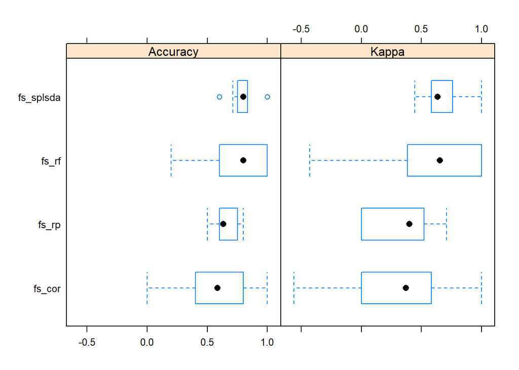

```r
models <- list(fs_cor=model_fs_cor, fs_rp=model_fs_rp, fs_rf=model_fs_rf,fs_splsda=model_fs_splsda)
bwplot(resamples(models))
```

```r
for (name in names(models)) {
    model <- get(paste0("cm_", name))
    print(paste0("cm_", name))
    print(as.data.frame(model$byClass))
}
```

```
## [1] "cm_fs_cor"
##                           Sensitivity Specificity Pos Pred Value
## Class: Female MSI-High      0.5000000   1.0000000      1.0000000
## Class: Female MSI-Low/MSS   0.8000000   0.7777778      0.8000000
## Class: Male MSI-High        1.0000000   0.9444444      0.5000000
## Class: Male MSI-Low/MSS     0.6666667   0.8461538      0.6666667
##                           Neg Pred Value Precision    Recall        F1
## Class: Female MSI-High         0.9444444 1.0000000 0.5000000 0.6666667
## Class: Female MSI-Low/MSS      0.7777778 0.8000000 0.8000000 0.8000000
## Class: Male MSI-High           1.0000000 0.5000000 1.0000000 0.6666667
## Class: Male MSI-Low/MSS        0.8461538 0.6666667 0.6666667 0.6666667
##                           Prevalence Detection Rate Detection Prevalence
## Class: Female MSI-High    0.10526316     0.05263158           0.05263158
## Class: Female MSI-Low/MSS 0.52631579     0.42105263           0.52631579
## Class: Male MSI-High      0.05263158     0.05263158           0.10526316
## Class: Male MSI-Low/MSS   0.31578947     0.21052632           0.31578947
##                           Balanced Accuracy
## Class: Female MSI-High            0.7500000
## Class: Female MSI-Low/MSS         0.7888889
## Class: Male MSI-High              0.9722222
## Class: Male MSI-Low/MSS           0.7564103
## [1] "cm_fs_rp"
##                           Sensitivity Specificity Pos Pred Value
## Class: Female MSI-High      0.5000000   0.8823529      0.3333333
## Class: Female MSI-Low/MSS   0.9000000   0.4444444      0.6428571
## Class: Male MSI-High        0.0000000   1.0000000            NaN
## Class: Male MSI-Low/MSS     0.3333333   1.0000000      1.0000000
##                           Neg Pred Value Precision    Recall   F1
## Class: Female MSI-High         0.9375000 0.3333333 0.5000000 0.40
## Class: Female MSI-Low/MSS      0.8000000 0.6428571 0.9000000 0.75
## Class: Male MSI-High           0.9473684        NA 0.0000000   NA
## Class: Male MSI-Low/MSS        0.7647059 1.0000000 0.3333333 0.50
##                           Prevalence Detection Rate Detection Prevalence
## Class: Female MSI-High    0.10526316     0.05263158            0.1578947
## Class: Female MSI-Low/MSS 0.52631579     0.47368421            0.7368421
## Class: Male MSI-High      0.05263158     0.00000000            0.0000000
## Class: Male MSI-Low/MSS   0.31578947     0.10526316            0.1052632
##                           Balanced Accuracy
## Class: Female MSI-High            0.6911765
## Class: Female MSI-Low/MSS         0.6722222
```

[output cut: 29 more lines]

```
##                           Neg Pred Value Precision    Recall        F1
## Class: Female MSI-High         1.0000000 0.6666667 1.0000000 0.8000000
## Class: Female MSI-Low/MSS      1.0000000 0.7692308 1.0000000 0.8695652
## Class: Male MSI-High           0.9444444 0.0000000 0.0000000       NaN
## Class: Male MSI-Low/MSS        0.7647059 1.0000000 0.3333333 0.5000000
##                           Prevalence Detection Rate Detection Prevalence
## Class: Female MSI-High    0.10526316      0.1052632           0.15789474
## Class: Female MSI-Low/MSS 0.52631579      0.5263158           0.68421053
## Class: Male MSI-High      0.05263158      0.0000000           0.05263158
## Class: Male MSI-Low/MSS   0.31578947      0.1052632           0.10526316
##                           Balanced Accuracy
## Class: Female MSI-High            0.9705882
## Class: Female MSI-Low/MSS         0.8333333
## Class: Male MSI-High              0.4722222
## Class: Male MSI-Low/MSS           0.6666667
```

# 4 Train Model

```r
library(caret)
# define training control
tc <- trainControl(method="repeatedcv", number=10)

# ---------------------------------------------------
# we will be using knn imputed test file &  Random Forest feature importance
# ---------------------------------------------------
train_set_final <- train_set_knn[, rf_features_impt]
train_set_final$class <- train_set_knn$class

classColNum <- grep("class",names(train_set_final))
mismatchColNum <- grep("mismatch",names(train_set_final))
# train_set_final[1:5,(ncol(train_set_final)-5):ncol(train_set_final)]
#
filenames = 'knn_imp_test.csv'
testX <-  read.table(filenames, header=T, sep = ",", stringsAsFactors=T, row.names = 1 )[,rf_features_impt]
testY <-  test_cli$class


# -------------------------------------------------------------------------------------
# This is the proprocess KNN-Imputed file that has features selected using sPLSDA
# ------------------------------------------------------------------------------------
train_sPLSDA<-train_set_knn[, selectedFeatures]
train_sPLSDA$class<-train_set_knn$class

filenames = 'knn_imp_test.csv'
testX_sPLSDA <-  read.table(filenames, header=T, sep = ",", stringsAsFactors=T, row.names = 1 )[,selectedFeatures]
testY_sPLSDA <-  test_cli$class
```

## 4.1 rpart

```r
library(rpart)
library(rpart.plot)
library(caret)
#-------------------------------------
# Using random Forest Feature Select
#-------------------------------------
set.seed(1)
rpart_fit <- train(class ~., data = train_set_final, trControl = tc ,
                   method = "rpart", parms=list(split='information'), tuneLength = 10)
rpart_fit
```

```
## CART
##
##  68 samples
## 610 predictors
##   4 classes: 'Female MSI-High', 'Female MSI-Low/MSS', 'Male MSI-High', 'Male MSI-Low/MSS'
##
## No pre-processing
## Resampling: Cross-Validated (10 fold, repeated 1 times)
## Summary of sample sizes: 62, 61, 61, 62, 61, 62, ...
## Resampling results across tuning parameters:
##
##   cp          Accuracy   Kappa
##   0.00000000  0.4297619   0.072023751
##   0.02614379  0.4297619   0.072023751
##   0.05228758  0.4297619   0.062023751
##   0.07843137  0.4464286   0.083023751
##   0.10457516  0.4464286   0.066242493
##   0.13071895  0.4464286   0.066242493
##   0.15686275  0.4214286   0.036648058
##   0.18300654  0.4196429  -0.004155564
##   0.20915033  0.4607143   0.007443182
##   0.23529412  0.4750000  -0.023333333
##
## Accuracy was used to select the optimal model using the largest value.
## The final value used for the model was cp = 0.2352941.
```

```r
pred_rp <- predict(rpart_fit, testX)
cm_rp_org <- confusionMatrix(pred_rp, testY)
cm_rp_org$byClass[7]
```

```
## [1] 1
```

```r
#-----------------------
# using sPLSDA
#-----------------------
set.seed(1)
rpart_fit_sPLSDA <- train(class ~., data = train_sPLSDA, trControl = tc ,
                   method = "rpart", parms=list(split='information'), tuneLength = 10)
rpart_fit_sPLSDA
```

```
## CART
##
##  68 samples
## 160 predictors
##   4 classes: 'Female MSI-High', 'Female MSI-Low/MSS', 'Male MSI-High', 'Male MSI-Low/MSS'
##
## No pre-processing
## Resampling: Cross-Validated (10 fold, repeated 1 times)
## Summary of sample sizes: 62, 61, 61, 62, 61, 62, ...
## Resampling results across tuning parameters:
##
##   cp          Accuracy   Kappa
##   0.00000000  0.3452381  -0.057191286
##   0.02614379  0.3452381  -0.057191286
##   0.05228758  0.3452381  -0.062039771
##   0.07843137  0.3452381  -0.062039771
##   0.10457516  0.3452381  -0.076325485
##   0.13071895  0.3595238  -0.057094716
##   0.15686275  0.3928571  -0.007094716
##   0.18300654  0.4196429   0.004352219
##   0.20915033  0.4464286  -0.039379975
##   0.23529412  0.4750000  -0.033333333
##
## Accuracy was used to select the optimal model using the largest value.
## The final value used for the model was cp = 0.2352941.
```

```r
pred_rp_splsda <- predict(rpart_fit_sPLSDA, testX_sPLSDA)
cm_rp_SPLSDA <- confusionMatrix(pred_rp_splsda, testY_sPLSDA)
cm_rp_SPLSDA$byClass[7]
```

```
## [1] 1
```

## 4.2 Random Forest

```r
set.seed(1)
library(randomForest)
rfGrid <-  expand.grid(mtry = c(2,4,6,8,10))
rf_fit <- train(class~., data = train_set_final, method="rf", trControl = tc ,tuneGrid = rfGrid, verbose=FALSE)
pred_rf <- predict(rf_fit, testX)
cm_rf_org <- confusionMatrix(pred_rf, testY)
cm_rf_org$byClass[7]
```

```
## [1] 1
```

```r
#-----------------------
# using sPLSDA
#-----------------------
set.seed(1)
rf_fit_sPLSDA <- train(class~., data = train_sPLSDA, method="rf", trControl = tc ,tuneGrid = rfGrid, verbose=FALSE)
rf_fit_sPLSDA
```

```
## Random Forest
##
##  68 samples
## 160 predictors
##   4 classes: 'Female MSI-High', 'Female MSI-Low/MSS', 'Male MSI-High', 'Male MSI-Low/MSS'
##
## No pre-processing
## Resampling: Cross-Validated (10 fold, repeated 1 times)
## Summary of sample sizes: 62, 61, 61, 62, 61, 62, ...
## Resampling results across tuning parameters:
##
##   mtry  Accuracy   Kappa
##    2    0.7833333  0.6292413
##    4    0.7666667  0.5965746
##    6    0.7523810  0.5763912
##    8    0.7541667  0.5712788
##   10    0.7541667  0.5695520
##
## Accuracy was used to select the optimal model using the largest value.
## The final value used for the model was mtry = 2.
```

```r
pred_rf_splsda <- predict(rf_fit_sPLSDA, testX_sPLSDA)
cm_rf_SPLSDA <- confusionMatrix(pred_rf_splsda, testY_sPLSDA)
cm_rf_SPLSDA$byClass[7]
```

```
## [1] 1
```

## 4.3 KNN

```r
classColNum <- grep("class",names(train_set))
mismatchColNum <- grep("mismatch",names(train_set))
set.seed(1)

knn_fit <- train(class ~., data =train_set_final, trControl = tc ,  method = "knn")
knn_fit
```

```
## k-Nearest Neighbors
##
##  68 samples
## 610 predictors
##   4 classes: 'Female MSI-High', 'Female MSI-Low/MSS', 'Male MSI-High', 'Male MSI-Low/MSS'
##
## No pre-processing
## Resampling: Cross-Validated (10 fold, repeated 1 times)
## Summary of sample sizes: 62, 61, 61, 62, 61, 62, ...
## Resampling results across tuning parameters:
##
##   k  Accuracy   Kappa
##   5  0.7107143  0.5427866
##   7  0.7785714  0.6305469
##   9  0.7619048  0.6019754
##
## Accuracy was used to select the optimal model using the largest value.
## The final value used for the model was k = 7.
```

```r
pred_knn <- predict(knn_fit, testX)
cm_knn_org <- confusionMatrix(pred_knn, testY)
cm_knn_org$byClass[7]
```

```
## [1] 0.9722222
```

```r
#-----------------------
# using sPLSDA
#-----------------------
set.seed(1)
knn_fit_sPLSDA <- train(class~., data = train_sPLSDA, trControl = tc ,  method = "knn")
knn_fit_sPLSDA
```

```
## k-Nearest Neighbors
##
##  68 samples
## 160 predictors
##   4 classes: 'Female MSI-High', 'Female MSI-Low/MSS', 'Male MSI-High', 'Male MSI-Low/MSS'
##
## No pre-processing
## Resampling: Cross-Validated (10 fold, repeated 1 times)
## Summary of sample sizes: 62, 61, 61, 62, 61, 62, ...
## Resampling results across tuning parameters:
##
##   k  Accuracy   Kappa
##   5  0.7190476  0.5589802
##   7  0.7065476  0.5362403
##   9  0.7809524  0.6434440
##
## Accuracy was used to select the optimal model using the largest value.
## The final value used for the model was k = 9.
```

```r
pred_knn_splsda <- predict(knn_fit_sPLSDA, testX_sPLSDA)
cm_knn_SPLDA <- confusionMatrix(pred_knn_splsda, testY_sPLSDA)
cm_knn_SPLDA$byClass[7]
```

```
## [1] 1
```

## 4.4 SVM

```r
classColNum <- grep("class",names(train_set))
mismatchColNum <- grep("mismatch",names(train_set))
set.seed(1)
library(e1071)
svm_fit <-train(class ~., data = train_set_final, trControl = tc ,  method="svmRadial" )
svm_fit
```

```
## Support Vector Machines with Radial Basis Function Kernel
##
##  68 samples
## 610 predictors
##   4 classes: 'Female MSI-High', 'Female MSI-Low/MSS', 'Male MSI-High', 'Male MSI-Low/MSS'
##
## No pre-processing
## Resampling: Cross-Validated (10 fold, repeated 1 times)
## Summary of sample sizes: 62, 61, 61, 62, 61, 62, ...
## Resampling results across tuning parameters:
##
##   C     Accuracy  Kappa
##   0.25  0.500000  0.0000000
##   0.50  0.500000  0.0000000
##   1.00  0.685119  0.4307587
##
## Tuning parameter 'sigma' was held constant at a value of 0.0008899526
## Accuracy was used to select the optimal model using the largest value.
## The final values used for the model were sigma = 0.0008899526 and C = 1.
```

```r
pred_svm <- predict(svm_fit, testX)
cm_svm_org <- confusionMatrix(pred_svm, testY)
cm_svm_org$byClass[7]
```

```
## [1] 1
```

```r
#-----------------------
# using sPLSDA
#-----------------------
set.seed(1)
svm_fit_sPLSDA <- train(class~., data = train_sPLSDA, trControl = tc ,  method = "knn")
svm_fit_sPLSDA
```

```
## k-Nearest Neighbors
##
##  68 samples
## 160 predictors
##   4 classes: 'Female MSI-High', 'Female MSI-Low/MSS', 'Male MSI-High', 'Male MSI-Low/MSS'
##
## No pre-processing
## Resampling: Cross-Validated (10 fold, repeated 1 times)
## Summary of sample sizes: 62, 61, 61, 62, 61, 62, ...
## Resampling results across tuning parameters:
##
##   k  Accuracy   Kappa
##   5  0.7190476  0.5589802
##   7  0.7065476  0.5362403
##   9  0.7809524  0.6434440
##
## Accuracy was used to select the optimal model using the largest value.
## The final value used for the model was k = 9.
```

```r
pred_svm_splsda <- predict(svm_fit_sPLSDA, testX_sPLSDA)
cm_svm_SPLSDA <- confusionMatrix(pred_svm_splsda, testY_sPLSDA)
cm_svm_SPLSDA$byClass[7]
```

```
## [1] 1
```

# 5 Result

## 5.1 Random Forest Variable Importance

```r
model_list <- list(KNN = knn_fit, SVM = svm_fit, RF = rf_fit, RP=rpart_fit)
resamps <- resamples(model_list)
resamps
```

```
##
## Call:
## resamples.default(x = model_list)
##
## Models: KNN, SVM, RF, RP
## Number of resamples: 10
## Performance metrics: Accuracy, Kappa
## Time estimates for: everything, final model fit
```

```r
for (name in names(models)) {
    model <- get(paste0("cm_", name))
    print(paste0("cm_", name))
    print(as.data.frame(model$byClass))
}
```

```
## [1] "cm_fs_cor"
##                           Sensitivity Specificity Pos Pred Value
## Class: Female MSI-High      0.5000000   1.0000000      1.0000000
## Class: Female MSI-Low/MSS   0.8000000   0.7777778      0.8000000
## Class: Male MSI-High        1.0000000   0.9444444      0.5000000
## Class: Male MSI-Low/MSS     0.6666667   0.8461538      0.6666667
##                           Neg Pred Value Precision    Recall        F1
## Class: Female MSI-High         0.9444444 1.0000000 0.5000000 0.6666667
## Class: Female MSI-Low/MSS      0.7777778 0.8000000 0.8000000 0.8000000
## Class: Male MSI-High           1.0000000 0.5000000 1.0000000 0.6666667
## Class: Male MSI-Low/MSS        0.8461538 0.6666667 0.6666667 0.6666667
##                           Prevalence Detection Rate Detection Prevalence
## Class: Female MSI-High    0.10526316     0.05263158           0.05263158
## Class: Female MSI-Low/MSS 0.52631579     0.42105263           0.52631579
## Class: Male MSI-High      0.05263158     0.05263158           0.10526316
## Class: Male MSI-Low/MSS   0.31578947     0.21052632           0.31578947
##                           Balanced Accuracy
## Class: Female MSI-High            0.7500000
## Class: Female MSI-Low/MSS         0.7888889
## Class: Male MSI-High              0.9722222
## Class: Male MSI-Low/MSS           0.7564103
## [1] "cm_fs_rp"
##                           Sensitivity Specificity Pos Pred Value
## Class: Female MSI-High      0.5000000   0.8823529      0.3333333
## Class: Female MSI-Low/MSS   0.9000000   0.4444444      0.6428571
## Class: Male MSI-High        0.0000000   1.0000000            NaN
## Class: Male MSI-Low/MSS     0.3333333   1.0000000      1.0000000
##                           Neg Pred Value Precision    Recall   F1
## Class: Female MSI-High         0.9375000 0.3333333 0.5000000 0.40
## Class: Female MSI-Low/MSS      0.8000000 0.6428571 0.9000000 0.75
## Class: Male MSI-High           0.9473684        NA 0.0000000   NA
## Class: Male MSI-Low/MSS        0.7647059 1.0000000 0.3333333 0.50
##                           Prevalence Detection Rate Detection Prevalence
## Class: Female MSI-High    0.10526316     0.05263158            0.1578947
## Class: Female MSI-Low/MSS 0.52631579     0.47368421            0.7368421
## Class: Male MSI-High      0.05263158     0.00000000            0.0000000
## Class: Male MSI-Low/MSS   0.31578947     0.10526316            0.1052632
##                           Balanced Accuracy
## Class: Female MSI-High            0.6911765
## Class: Female MSI-Low/MSS         0.6722222
```

[output cut: 29 more lines]

```
##                           Neg Pred Value Precision    Recall        F1
## Class: Female MSI-High         1.0000000 0.6666667 1.0000000 0.8000000
## Class: Female MSI-Low/MSS      1.0000000 0.7692308 1.0000000 0.8695652
## Class: Male MSI-High           0.9444444 0.0000000 0.0000000       NaN
## Class: Male MSI-Low/MSS        0.7647059 1.0000000 0.3333333 0.5000000
##                           Prevalence Detection Rate Detection Prevalence
## Class: Female MSI-High    0.10526316      0.1052632           0.15789474
## Class: Female MSI-Low/MSS 0.52631579      0.5263158           0.68421053
## Class: Male MSI-High      0.05263158      0.0000000           0.05263158
## Class: Male MSI-Low/MSS   0.31578947      0.1052632           0.10526316
##                           Balanced Accuracy
## Class: Female MSI-High            0.9705882
## Class: Female MSI-Low/MSS         0.8333333
## Class: Male MSI-High              0.4722222
## Class: Male MSI-Low/MSS           0.6666667
```

```r
# summarize differences between modes
summary(resamps)
```

```
##
## Call:
## summary.resamples(object = resamps)
##
## Models: KNN, SVM, RF, RP
## Number of resamples: 10
##
## Accuracy
##          Min.   1st Qu.    Median      Mean   3rd Qu.      Max. NA's
## KNN 0.6666667 0.6785714 0.7321429 0.7785714 0.8303571 1.0000000    0
## SVM 0.5000000 0.6354167 0.6904762 0.6851190 0.7142857 1.0000000    0
## RF  0.5000000 0.6354167 0.6904762 0.6994048 0.7410714 1.0000000    0
## RP  0.2500000 0.4464286 0.5000000 0.4750000 0.5000000 0.5714286    0
##
## Kappa
##           Min.   1st Qu.    Median        Mean   3rd Qu. Max. NA's
## KNN  0.3913043 0.4659091 0.5827506  0.63054686 0.7455882  1.0    0
## SVM  0.0000000 0.3126935 0.3956522  0.43075873 0.5589718  1.0    0
## RF   0.0000000 0.3126935 0.4229249  0.44446544 0.5870968  1.0    0
## RP  -0.3333333 0.0000000 0.0000000 -0.02333333 0.0000000  0.1    0
```

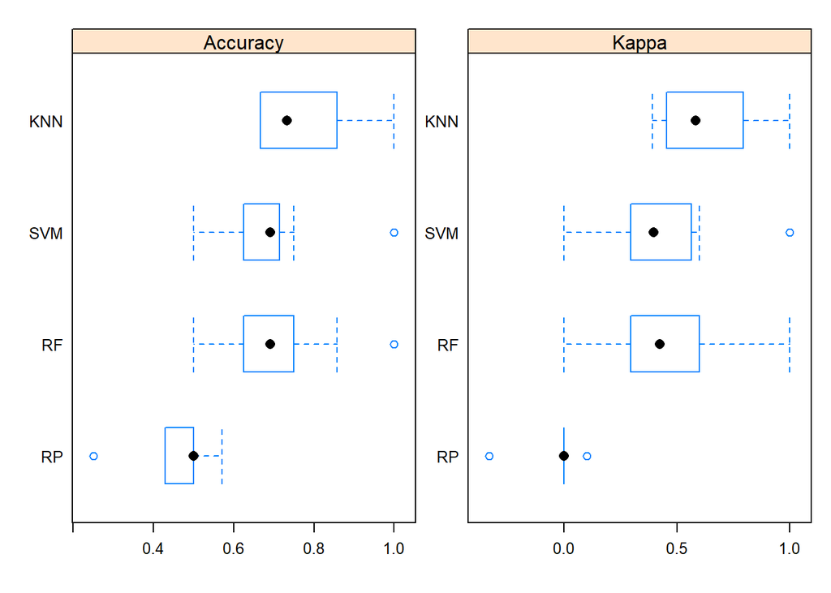

```r
# box and whisker plots to compare models
scales <- list(x=list(relation="free"), y=list(relation="free"))
bwplot(resamps, scales=scales)
```

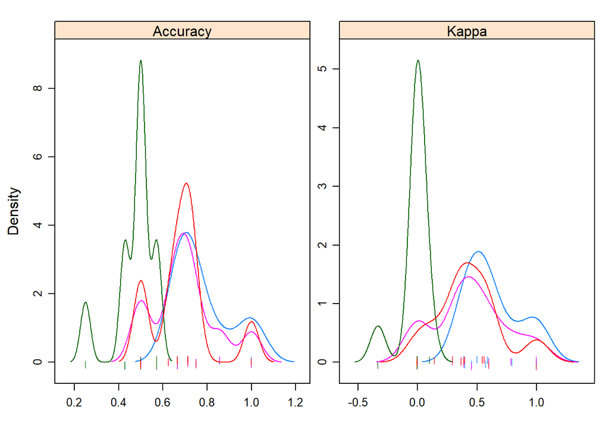

```r
# density plots of accuracy
densityplot(resamps, scales=scales, pch = "|")
```

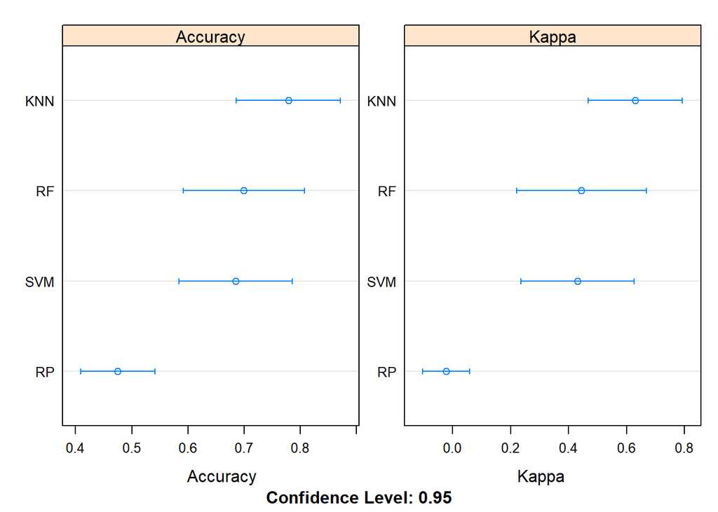

```r
# dot plots of accuracy
dotplot(resamps, scales=scales)
```

```r
# difference in model predictions
diffs <- diff(resamps)

# summarize p-values for pair-wise comparisons
summary(diffs)
```

```
##
## Call:
## summary.diff.resamples(object = diffs)
##
## p-value adjustment: bonferroni
## Upper diagonal: estimates of the difference
## Lower diagonal: p-value for H0: difference = 0
##
## Accuracy
##     KNN       SVM       RF        RP
## KNN            0.09345   0.07917   0.30357
## SVM 0.1695718           -0.01429   0.21012
## RF  0.9141620 1.0000000            0.22440
## RP  0.0006353 0.0073113 0.0090220
##
## Kappa
##     KNN       SVM      RF       RP
## KNN            0.19979  0.18608  0.65388
## SVM 0.088894           -0.01371  0.45409
## RF  0.584909  1.000000           0.46780
## RP  5.268e-05 0.003771 0.009530
```

```r
#
```

## 5.2 sPLSDA

```r
model_list <- list(KNN = knn_fit_sPLSDA, SVM = svm_fit_sPLSDA, RF = rf_fit_sPLSDA, RP=rpart_fit_sPLSDA)
resamps <- resamples(model_list)
resamps
```

```
##
## Call:
## resamples.default(x = model_list)
##
## Models: KNN, SVM, RF, RP
## Number of resamples: 10
## Performance metrics: Accuracy, Kappa
## Time estimates for: everything, final model fit
```

```r
for (name in names(models)) {
    model <- get(paste0("cm_", name))
    print(paste0("cm_", name))
    print(as.data.frame(model$byClass))
}
```

```
## [1] "cm_fs_cor"
##                           Sensitivity Specificity Pos Pred Value
## Class: Female MSI-High      0.5000000   1.0000000      1.0000000
## Class: Female MSI-Low/MSS   0.8000000   0.7777778      0.8000000
## Class: Male MSI-High        1.0000000   0.9444444      0.5000000
## Class: Male MSI-Low/MSS     0.6666667   0.8461538      0.6666667
##                           Neg Pred Value Precision    Recall        F1
## Class: Female MSI-High         0.9444444 1.0000000 0.5000000 0.6666667
## Class: Female MSI-Low/MSS      0.7777778 0.8000000 0.8000000 0.8000000
## Class: Male MSI-High           1.0000000 0.5000000 1.0000000 0.6666667
## Class: Male MSI-Low/MSS        0.8461538 0.6666667 0.6666667 0.6666667
##                           Prevalence Detection Rate Detection Prevalence
## Class: Female MSI-High    0.10526316     0.05263158           0.05263158
## Class: Female MSI-Low/MSS 0.52631579     0.42105263           0.52631579
## Class: Male MSI-High      0.05263158     0.05263158           0.10526316
## Class: Male MSI-Low/MSS   0.31578947     0.21052632           0.31578947
##                           Balanced Accuracy
## Class: Female MSI-High            0.7500000
## Class: Female MSI-Low/MSS         0.7888889
## Class: Male MSI-High              0.9722222
## Class: Male MSI-Low/MSS           0.7564103
## [1] "cm_fs_rp"
##                           Sensitivity Specificity Pos Pred Value
## Class: Female MSI-High      0.5000000   0.8823529      0.3333333
## Class: Female MSI-Low/MSS   0.9000000   0.4444444      0.6428571
## Class: Male MSI-High        0.0000000   1.0000000            NaN
## Class: Male MSI-Low/MSS     0.3333333   1.0000000      1.0000000
##                           Neg Pred Value Precision    Recall   F1
## Class: Female MSI-High         0.9375000 0.3333333 0.5000000 0.40
## Class: Female MSI-Low/MSS      0.8000000 0.6428571 0.9000000 0.75
## Class: Male MSI-High           0.9473684        NA 0.0000000   NA
## Class: Male MSI-Low/MSS        0.7647059 1.0000000 0.3333333 0.50
##                           Prevalence Detection Rate Detection Prevalence
## Class: Female MSI-High    0.10526316     0.05263158            0.1578947
## Class: Female MSI-Low/MSS 0.52631579     0.47368421            0.7368421
## Class: Male MSI-High      0.05263158     0.00000000            0.0000000
## Class: Male MSI-Low/MSS   0.31578947     0.10526316            0.1052632
##                           Balanced Accuracy
## Class: Female MSI-High            0.6911765
## Class: Female MSI-Low/MSS         0.6722222
```

[output cut: 29 more lines]

```
##                           Neg Pred Value Precision    Recall        F1
## Class: Female MSI-High         1.0000000 0.6666667 1.0000000 0.8000000
## Class: Female MSI-Low/MSS      1.0000000 0.7692308 1.0000000 0.8695652
## Class: Male MSI-High           0.9444444 0.0000000 0.0000000       NaN
## Class: Male MSI-Low/MSS        0.7647059 1.0000000 0.3333333 0.5000000
##                           Prevalence Detection Rate Detection Prevalence
## Class: Female MSI-High    0.10526316      0.1052632           0.15789474
## Class: Female MSI-Low/MSS 0.52631579      0.5263158           0.68421053
## Class: Male MSI-High      0.05263158      0.0000000           0.05263158
## Class: Male MSI-Low/MSS   0.31578947      0.1052632           0.10526316
##                           Balanced Accuracy
## Class: Female MSI-High            0.9705882
## Class: Female MSI-Low/MSS         0.8333333
## Class: Male MSI-High              0.4722222
## Class: Male MSI-Low/MSS           0.6666667
```

```r
# summarize differences between modes
summary(resamps)
```

```
##
## Call:
## summary.resamples(object = resamps)
##
## Models: KNN, SVM, RF, RP
## Number of resamples: 10
##
## Accuracy
##          Min.   1st Qu.    Median      Mean   3rd Qu.      Max. NA's
## KNN 0.6250000 0.6785714 0.7142857 0.7809524 0.8645833 1.0000000    0
## SVM 0.6250000 0.6785714 0.7142857 0.7809524 0.8645833 1.0000000    0
## RF  0.5714286 0.7232143 0.7916667 0.7833333 0.8333333 1.0000000    0
## RP  0.2500000 0.4464286 0.5000000 0.4750000 0.5000000 0.5714286    0
##
## Kappa
##           Min.   1st Qu.    Median        Mean   3rd Qu. Max. NA's
## KNN  0.3684211 0.4709091 0.5757576  0.64344403 0.7919255    1    0
## SVM  0.3684211 0.4709091 0.5757576  0.64344403 0.7919255    1    0
## RF   0.3437500 0.5501792 0.6500000  0.62924131 0.7107143    1    0
## RP  -0.3333333 0.0000000 0.0000000 -0.03333333 0.0000000    0    0
```

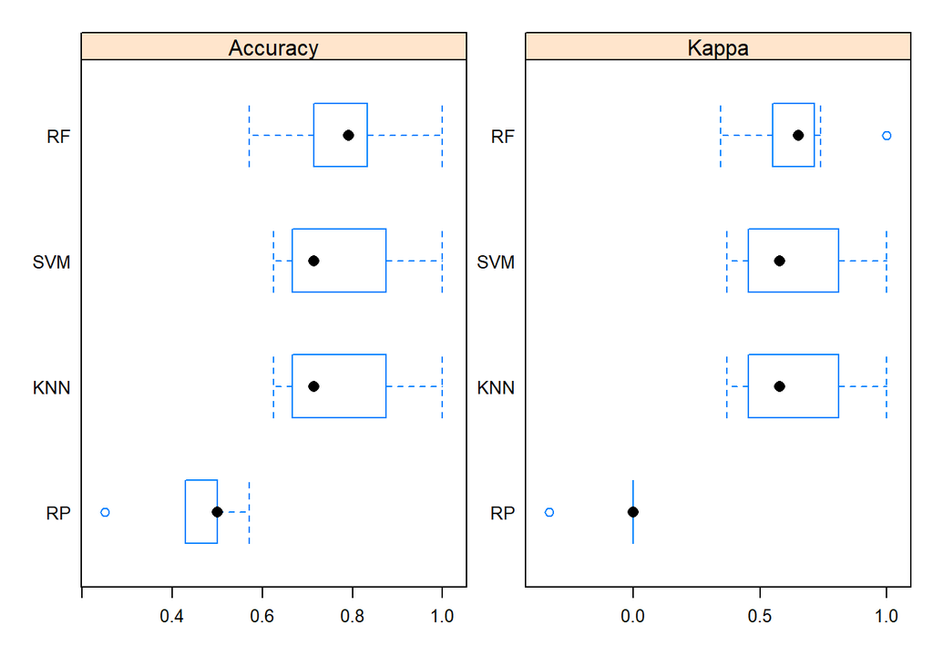

```r
# box and whisker plots to compare models
scales <- list(x=list(relation="free"), y=list(relation="free"))
bwplot(resamps, scales=scales)
```

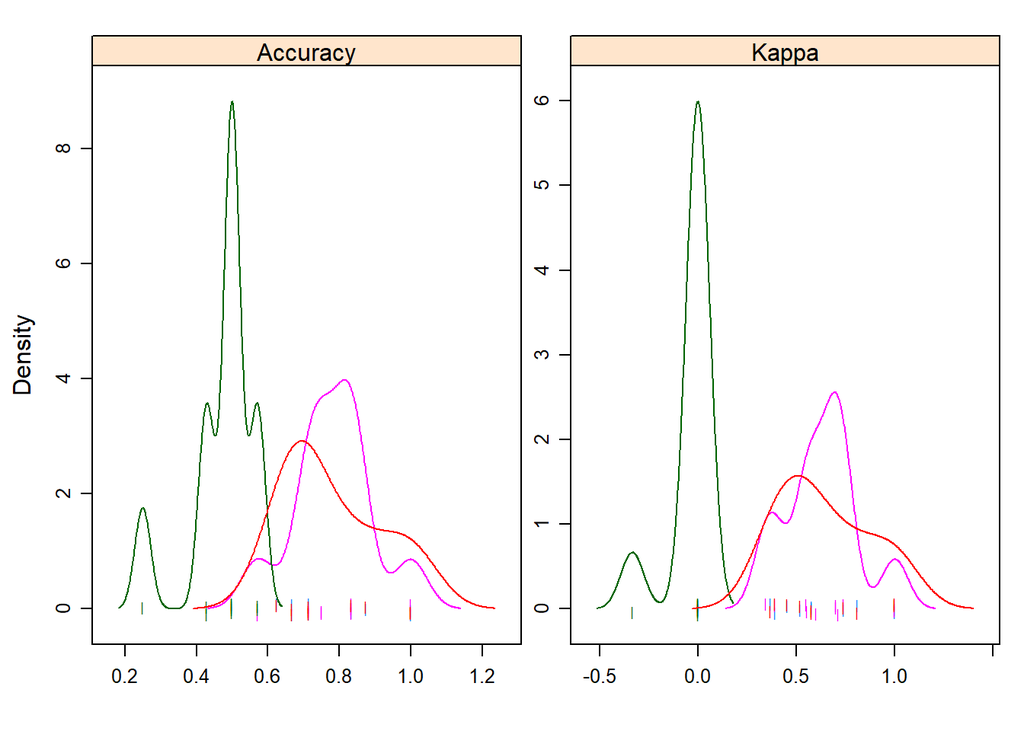

```r
# density plots of accuracy
densityplot(resamps, scales=scales, pch = "|")
```

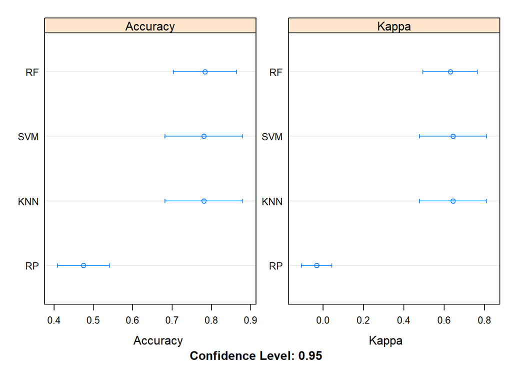

```r
# dot plots of accuracy
dotplot(resamps, scales=scales)
```

```r
# difference in model predictions
diffs <- diff(resamps)

# summarize p-values for pair-wise comparisons
summary(diffs)
```

```
##
## Call:
## summary.diff.resamples(object = diffs)
##
## p-value adjustment: bonferroni
## Upper diagonal: estimates of the difference
## Lower diagonal: p-value for H0: difference = 0
##
## Accuracy
##     KNN      SVM       RF        RP
## KNN           0.000000 -0.002381  0.305952
## SVM NA                 -0.002381  0.305952
## RF  1.000000 1.000000             0.308333
## RP  0.001369 0.001369  5.494e-05
##
## Kappa
##     KNN      SVM      RF        RP
## KNN          0.0000   0.0142    0.6768
## SVM NA                0.0142    0.6768
## RF  1.000000 1.000000           0.6626
## RP  0.000155 0.000155 1.339e-05
```

```r
#
```

## 5.3 AUC

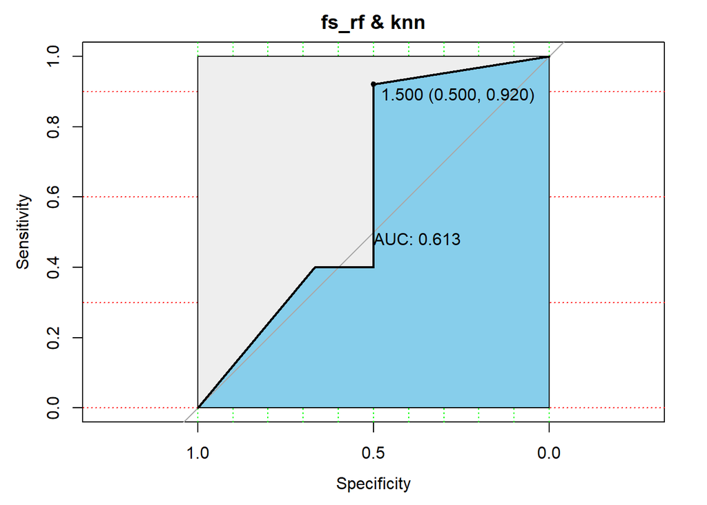

```r
#install.packages("pROC")
library(pROC)

modelroc1 <- roc(testY,as.numeric(pred_knn))
modelroc2 <- roc(testY,as.numeric(pred_rf_splsda))

plot(modelroc1, print.auc=TRUE, auc.polygon=TRUE, grid=c(0.1, 0.3),
     grid.col=c("green", "red"), max.auc.polygon=TRUE,
     auc.polygon.col="skyblue", print.thres=TRUE,main=("fs_rf & knn"))
```

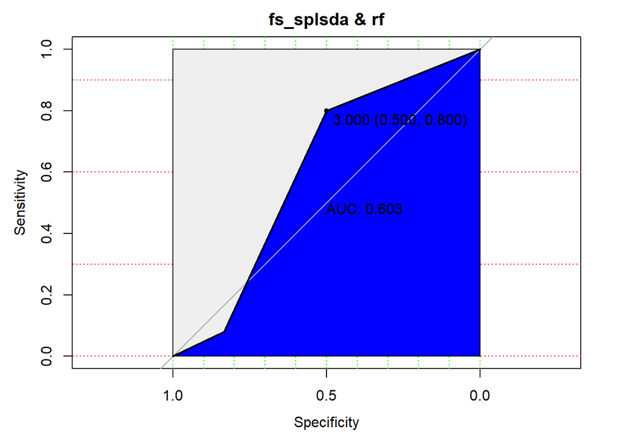

```r
plot(modelroc2,print.auc=TRUE, auc.polygon=TRUE, grid=c(0.1, 0.3),
     grid.col=c("green", "red"), max.auc.polygon=TRUE,
    auc.polygon.col="blue", print.thres=TRUE,main="fs_splsda & rf")
```

```r
#plot(modelroc1)
```

# 6 Others

## 6.1 Mismatch Labels

The all the above analysis was run using 0-match label. This section will run the same code but on all 80 dataset and try to predict class

```r
# ---------------------------------------------------
# Load sPLSDA test file to be used for SVM
# ---------------------------------------------------
filenames = 'train_knn_1.csv'
train_sPLSDA  <-  read.table(filenames, header=T, sep = ",", stringsAsFactors=T, row.names = 1 )
# train_sPLSDA[1:5, (mismatchColNum-5) :mismatchColNum]
dim(train_sPLSDA)
```

```
## [1]  80 162
```

```r
mismatchColNum <- grep("mismatch", names(train_sPLSDA))

filenames = 'test_knn_1.csv'
testX_sPLSDA <-  read.table(filenames, header=T, sep = ",", stringsAsFactors=T, row.names = 1 )
testY_sPLSDA <-  testX_sPLSDA$class
# testX_sPLSDA[1:5,(ncol(testX_sPLSDA)-5):ncol(testX_sPLSDA)]
dim(testX_sPLSDA)
```

```
## [1]  80 161
```

```r
# run against knn
final_fit <- train(class ~., data =train_sPLSDA[, -mismatchColNum], trControl = tc ,  method = "knn")
final_fit
```

```
## k-Nearest Neighbors
##
##  80 samples
## 160 predictors
##   4 classes: 'Female MSI-High', 'Female MSI-Low/MSS', 'Male MSI-High', 'Male MSI-Low/MSS'
##
## No pre-processing
## Resampling: Cross-Validated (10 fold, repeated 1 times)
## Summary of sample sizes: 73, 71, 71, 71, 72, 73, ...
## Resampling results across tuning parameters:
##
##   k  Accuracy   Kappa
##   5  0.6333333  0.3872695
##   7  0.6962302  0.5023897
##   9  0.6948413  0.4860601
##
## Accuracy was used to select the optimal model using the largest value.
## The final value used for the model was k = 7.
```

```r
final <- as.data.frame(testX_sPLSDA$match, predict=predict(final_fit, testX_sPLSDA))
#confusionMatrix(pred_knn, testX_sPLSDA)
```

> As expected, accuracy dropped slightyly.

## 6.2 Output files

1. Probability of each sample been mislabelled

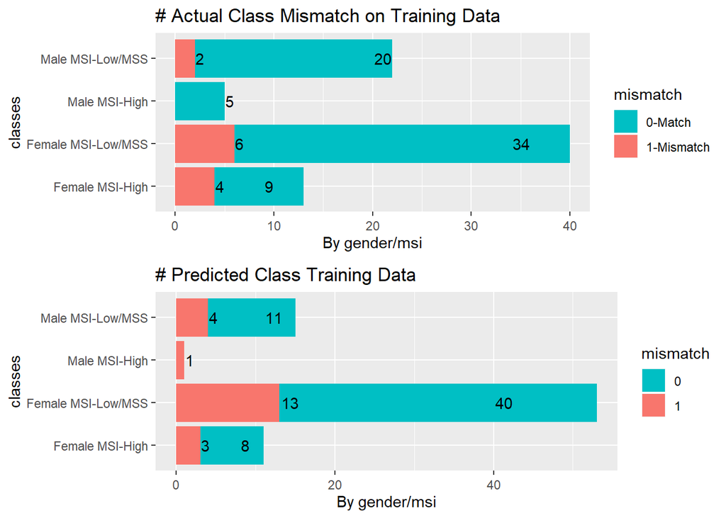

```r
library(ggplot2)
library(scales)
library(gridExtra)

# Imputed KNN using Random Forest Feature Selection against KNN returns highest test accuracy
final <- c()
final$mismatch <- train_sPLSDA$mismatch
final$actual  <- train_sPLSDA$class

# dump probability of training sample mislabeled
pred$actualClass <- train_sPLSDA$class
pred$actualMismatch <- train_sPLSDA$mismatch
pred$prob <- predict(final_fit, train_sPLSDA, type="prob")
pred$predClass <- predict(final_fit, train_sPLSDA )

pred$predMismatch <- ifelse( train_sPLSDA$class == predict(final_fit, train_sPLSDA),0,1 )
write.csv(train_sPLSDA$mismatch , file=paste("1_train_prob_mislabel.csv"))

# actual
g1 <- ggplot(train_sPLSDA, aes(x = class, fill=mismatch)) +
    geom_bar(aes(y = (..count..))) +
    geom_text(aes(y =  ((..count..)) , label = ((..count..))) , stat = "count", vjust = 0.5, hjust=-0.1) +
    coord_flip() + # flip horizontal
    theme(axis.text.x = element_text(angle=0, vjust=0.6)) +
    labs(title = "# Actual Class Mismatch on Training Data", y = "By gender/msi", x = "classes") +
    theme(legend.position="right") +
    scale_fill_manual(values=gr_pallete)


# predicted
g2 <- ggplot(data.frame(class=pred$predClass, mismatch=as.factor(pred$predMismatch)), aes(x = class, fill=mismatch)) +
    geom_bar(aes(y = (..count..))) +
    geom_text(aes(y =  ((..count..)) , label = ((..count..))) , stat = "count", vjust = 0.5, hjust=-0.1) +
    coord_flip() + # flip horizontal
    theme(axis.text.x = element_text(angle=0, vjust=0.6)) +
    labs(title = "# Predicted Class Training Data", y = "By gender/msi", x = "classes") +
    theme(legend.position="right") +
    scale_fill_manual(values=gr_pallete)


grid.arrange(g1,g2,nrow=2, ncol=1)
```

# 7 Evaluation Criteria

The evaluation of any machine learning model or algorithm forms a critical key to achieving a viable outcome for any serious study. The model may provide satisfying results when evaluated using a metric such as accuracy score but may provide unhelpful results when other metrics, such as logarithmic loss or similar, are used. While classification accuracy is commonly used to quantify the performance of our model, it is insufficient to realistically evaluate our model with a high level of confidence.

For this study, we used a variety of different evaluation metrics from the types that were available to us. Classification accuracy is usually what we actually mean when we use accuracy as a shortcut term. It is defined as the ratio of the number of correct predictions to the total number of input samples. This only works well if you have an equal number of samples comprised in each class.

Classification accuracy appears fine but can often give the incorrect impression that a high level of accuracy has been recorded. A significant difficulty arises, when the negative effect of misclassifying of minor class samples peaks. To illustrate the point: when dealing with a rare but usually terminal cancer, the cost of failing to diagnose the precise type of cancer is much higher than the cost undertaking the full range of necessary diagnostic tests. Confusion matrix, as the name indicates, gave us a matrix as output which describe the complete performance of our model. These four important terms are commonly used in confusion matrix -

- True Positives (TP)
- True Negatives (TN)
- False Positives (FP)
- False Negatives (FN)

Area Under Curve (AUC) is a very commonly used evaluation metric, especially for problems with binary classification. The AUC of a classifier is equal to the probability that the classifier will rank a randomly chosen positive example higher than a randomly chosen negative example. In defining the AUC, we need to be aware of these two basic terms: * True Positive Rate (Sensitivity): The True Positive Rate is defined as TP/ (FN+TP). This corresponds with the proportion of positive data points that may be correctly considered as positive, with respect to all of the positive data points. * False Positive Rate (Specificity): The False Positive Rate is defined as FP / (FP+TN). This corresponds to the proportion of negative data points that are mistakenly considered as positive, with respect to all of the negative data points. Confusion matrix can also be a basis for metrics of other types.

The F1 Score is the Harmonic Mean between precision and recall. The range for the F1 Score is [0,1]. This lets you know the accuracy and precision of your classifier (how many instances are correctly classified), and how solid and robust it is (a significant number of instances are not ignored).

Having high precision but lower recall gives you an extremely accurate result. However, it can then miss very many instances that were difficult to classify. The higher the F1 Score, the greater the performance of our model. F1 Score aims to find a balance between precision and recall, defined as follows: Precision: The number of correct positive results divided by the number of positive results, as predicted by the classifier. Recall: The number of correct positive results divided by the number of all relevant samples (that is, all samples that should have been identified as positive).

# 8 Conclusion

For this study, we were required to identify a dataset that was potentially mis-labelled. We observed and evaluated a variety of data imputation methods, feature selections and algorithms, and identified 2 classifiers and compare the combination of feature selection method.

We demonstrate that by up-sampling a dataset, as a converse to imbalance, that distribution accuracy and F1 has decreased. Commonly used algorithms do not allow for data distribution and are often found to be biased in favour of the majority class. Thus, it is essential that an imbalanced dataset gets special attention to ensure that both minority and majority classes are properly represented. Initial speculation is upsampling on this datset creates an equal distribution of the four classes which may have resulted in over fitting.

# 9 Contribution

- $+$ indicates percentage of coding
- $o$ documentation & analysis

| Section | Melissa | Zhuoyang | Josh | Biji | Sergio |
| --- | --- | --- | --- | --- | --- |
| Introduction |  |  |  |  |  |
| Data Load | + | + | + | + | + |
| **Data Imputation** |  |  |  |  |  |
| -Mean |  |  | +o | o |  |
| -Median |  |  |  | +o |  |
| -KNN Inputation |  | +o |  |  |  |
| -Missknn | +o |  |  |  |  |
| **Class Imbalance** | + |  | o | o |  |
| **Feature Selection** |  |  |  |  |  |
| -Correlated Predictor | + |  | o | o | o |
| -Feature Importance rpart | + |  | o | o | o |
| -Feature Importance RF |  | + | o | o | o |
| -PCA | + | + |  |  |  |
| -SPLSDA |  | +o | o |  |  |
| **Train Model** |  |  |  |  |  |
| Rpart | + |  |  |  |  |
| Random Forest |  | + |  |  |  |
| KNN |  |  | + |  |  |
| SVM |  |  |  | + |  |
| **Fine Tune Parameter** | + | + | + | + |  |
| **Predict Class** | + | + |  |  |  |
| **Conclusion** | o | o | o | o |  |
| **Analysis/Powerpoint** |  | o | o | o | o |

# 10 Reference

[1] Wicked Good Data, Handling Class Imbalance with R and Caret – An Introduction, accessed 28 Oct 2018, https://www.r-bloggers.com/handling-class-imbalance-with-r-and-caret-an-introduction/

[2] Jonathan A C Sterne, Michael Sprat, James R Carpenter, Jun 2009, Multiple imputation for missing data in epidemiological and clinical research: potential and pitfalls, BMJ 2009;338:b2393, accessed 28 Oct 2018, https://www.bmj.com/content/338/bmj.b2393.full.pdf+html

[3] Mandel J, S. (2015). A Comparison of Six Methods for Missing Data Imputation. Journal Of Biometrics & Biostatistics, 06(01). doi: 10.4172/2155-6180.1000224

[4] Joachim, Statistical Programming, accessed 28 Oct 2018, https://statistical-programming.com/mean-imputation-for-missing-data/

[5] Wale Akinfaderin, Missing Data Conundrum: Exploration and Imputation Techniques, accessed 28 Oct 2018, https://medium.com/ibm-data-science-experience/missing-data-conundrum-exploration-and-imputation-techniques-9f40abe0fd87

[6] Sagar, C. (2018). Feature selection techniques with R. Retrieved from http://dataaspirant.com/2018/01/15/feature-selection-techniques-r/

[7] Kazemitabar, J. et. al. (2018). Retrieved from https://www.cs.cmu.edu/~atalwalk/dstump_nips17.pdf

[8] Gluck, C. (2018). Running Random Forests? Inspect the feature importances with this code. Retrieved from https://towardsdatascience.com/running-random-forests-inspect-the-feature-importances-with-this-code-2b00dd72b92e

[9] Saabas, A. (2018). Selecting good features – Part IV: stability selection, RFE and everything side by side | Diving into data. Retrieved from https://blog.datadive.net/selecting-good-features-part-iv-stability-selection-rfe-and-everything-side-by-side/

[10] PLS-DA | mixOmics. (2018). Retrieved from http://mixomics.org/methods/pls-da/ [11] Lê Cao, K., Boitard, S., & Besse, P. (2018). Sparse PLS discriminant analysis: biologically relevant feature selection and graphical displays for multiclass problems.